# Project: Investigate a Dataset (TMDB movie)

- Introduction
- Data Wrangling
- Exploratory Data Analysis
- Conclusions

## Introduction

### Analysing The TMDB Movie Dataset

> This data contain and hold more than 10,000 movies information,it's include user ratings, revenue, imdb id and release date.

> Questions will be asked to help in these analysing of this dataset.

### Columns Description

> **A. id :** Rows Id.

> **B. imdb_id :** IMBD Id.

> **C. popularity :** The Popularity of The Movie.

> **D. budget :** The Budget of The Movie.

> **E. revenue :** The Revenue of The Movie.

> **F. original_title :** The Movie Name.

> **G. cast :** Cast Worked in The Movie.

> **H. homepage :** Link To The Movie Site.

> **I. director :** The Director of The Movie.

> **J. tagline :** The Tagline of The Movie.

> **K. keywords :** Keywords of The Moive.

> **L. overview :** The Overview About The Moive.

> **M. runtime :** The Duration of The Moive(min).

> **N. genres :** The Category of The Movie.

> **O. production_companies :** The Production Company Name.

> **P. release_date :** The Date Which The Moive Released.

> **Q. vote_count :** The Vote Count.

> **R. vote_average :** The Average Vote Count.

> **S. release_year :** The Year Which The Moive Released.

> **T. budget_adj :** Budget in Dollars in 2010.

> **U. revenue_adj :** Revenue in Dollars in 2010.

### Project Steps

> 1 - Data Wrangling

> 2 - Data Cleaning

> 3 - Exploratory Data Analysis

> 4 - Conclusions

> 5 - limitations

### Project Overview

> **The Movie Database will be the source of my research for this project.**

> **Questions to answer:-.**

> 1 - Which genres are most popular?

> 2 - What kinds of properties are associated with movies that have high revenues ?

> 3 - Which cast is most popular ?

> 4 - Which director is most popular ?

> 5 - Which production company is most popular ?

```python
# Use this cell to set up import statements for all of the packages that you plan to use.
import pandas as pd
import numpy as np
import matplotlib.pyplot as plt
import seaborn as sns
% matplotlib inline
```

## Data Wrangling

> **In this section the dataset should be understanding very well and be clean to me in my mind to help me to asnlysis this dataset very properly.**:

### General Properties

```python
# Load your data and print out a few lines. Perform operations to inspect data
#   types and look for instances of missing or possibly errant data.
df = pd.read_csv('tmdb-movies.csv')
df.head()
```

|  | id | imdb_id | popularity | budget | revenue | original_title | cast | homepage | director | tagline | ... | overview | runtime | genres | production_companies | release_date | vote_count | vote_average | release_year | budget_adj | revenue_adj |
| --- | --- | --- | --- | --- | --- | --- | --- | --- | --- | --- | --- | --- | --- | --- | --- | --- | --- | --- | --- | --- | --- |
| 0 | 135397 | tt0369610 | 32.985763 | 150000000 | 1513528810 | Jurassic World | Chris Pratt\|Bryce Dallas Howard\|Irrfan Khan\|Vi... | http://www.jurassicworld.com/ | Colin Trevorrow | The park is open. | ... | Twenty-two years after the events of Jurassic ... | 124 | Action\|Adventure\|Science Fiction\|Thriller | Universal Studios\|Amblin Entertainment\|Legenda... | 6/9/2015 | 5562 | 6.5 | 2015 | 137999939.3 | 1.392446e+09 |
| 1 | 76341 | tt1392190 | 28.419936 | 150000000 | 378436354 | Mad Max: Fury Road | Tom Hardy\|Charlize Theron\|Hugh Keays-Byrne\|Nic... | http://www.madmaxmovie.com/ | George Miller | What a Lovely Day. | ... | An apocalyptic story set in the furthest reach... | 120 | Action\|Adventure\|Science Fiction\|Thriller | Village Roadshow Pictures\|Kennedy Miller Produ... | 5/13/2015 | 6185 | 7.1 | 2015 | 137999939.3 | 3.481613e+08 |
| 2 | 262500 | tt2908446 | 13.112507 | 110000000 | 295238201 | Insurgent | Shailene Woodley\|Theo James\|Kate Winslet\|Ansel... | http://www.thedivergentseries.movie/#insurgent | Robert Schwentke | One Choice Can Destroy You | ... | Beatrice Prior must confront her inner demons ... | 119 | Adventure\|Science Fiction\|Thriller | Summit Entertainment\|Mandeville Films\|Red Wago... | 3/18/2015 | 2480 | 6.3 | 2015 | 101199955.5 | 2.716190e+08 |
| 3 | 140607 | tt2488496 | 11.173104 | 200000000 | 2068178225 | Star Wars: The Force Awakens | Harrison Ford\|Mark Hamill\|Carrie Fisher\|Adam D... | http://www.starwars.com/films/star-wars-episod... | J.J. Abrams | Every generation has a story. | ... | Thirty years after defeating the Galactic Empi... | 136 | Action\|Adventure\|Science Fiction\|Fantasy | Lucasfilm\|Truenorth Productions\|Bad Robot | 12/15/2015 | 5292 | 7.5 | 2015 | 183999919.0 | 1.902723e+09 |
| 4 | 168259 | tt2820852 | 9.335014 | 190000000 | 1506249360 | Furious 7 | Vin Diesel\|Paul Walker\|Jason Statham\|Michelle ... | http://www.furious7.com/ | James Wan | Vengeance Hits Home | ... | Deckard Shaw seeks revenge against Dominic Tor... | 137 | Action\|Crime\|Thriller | Universal Pictures\|Original Film\|Media Rights ... | 4/1/2015 | 2947 | 7.3 | 2015 | 174799923.1 | 1.385749e+09 |

5 rows × 21 columns

> **The tmdb dataset contains 10866 rows and 21 columns.**.

```python
# The shape of the dataset
df.shape
```

```
(10866, 21)
```

```python
# Information about the dataset
df.info()
```

```
<class 'pandas.core.frame.DataFrame'>
RangeIndex: 10866 entries, 0 to 10865
Data columns (total 21 columns):
id                      10866 non-null int64
imdb_id                 10856 non-null object
popularity              10866 non-null float64
budget                  10866 non-null int64
revenue                 10866 non-null int64
original_title          10866 non-null object
cast                    10790 non-null object
homepage                2936 non-null object
director                10822 non-null object
tagline                 8042 non-null object
keywords                9373 non-null object
overview                10862 non-null object
runtime                 10866 non-null int64
genres                  10843 non-null object
production_companies    9836 non-null object
release_date            10866 non-null object
vote_count              10866 non-null int64
vote_average            10866 non-null float64
release_year            10866 non-null int64
budget_adj              10866 non-null float64
revenue_adj             10866 non-null float64
dtypes: float64(4), int64(6), object(11)
memory usage: 1.7+ MB
```

> **View of datasets to check for correct datatypes, null values, duplicate values.**.

```python
# Description about the dataset
df.describe()
```

|  | id | popularity | budget | revenue | runtime | vote_count | vote_average | release_year | budget_adj | revenue_adj |
| --- | --- | --- | --- | --- | --- | --- | --- | --- | --- | --- |
| count | 10866.000000 | 10866.000000 | 1.086600e+04 | 1.086600e+04 | 10866.000000 | 10866.000000 | 10866.000000 | 10866.000000 | 1.086600e+04 | 1.086600e+04 |
| mean | 66064.177434 | 0.646441 | 1.462570e+07 | 3.982332e+07 | 102.070863 | 217.389748 | 5.974922 | 2001.322658 | 1.755104e+07 | 5.136436e+07 |
| std | 92130.136561 | 1.000185 | 3.091321e+07 | 1.170035e+08 | 31.381405 | 575.619058 | 0.935142 | 12.812941 | 3.430616e+07 | 1.446325e+08 |
| min | 5.000000 | 0.000065 | 0.000000e+00 | 0.000000e+00 | 0.000000 | 10.000000 | 1.500000 | 1960.000000 | 0.000000e+00 | 0.000000e+00 |
| 25% | 10596.250000 | 0.207583 | 0.000000e+00 | 0.000000e+00 | 90.000000 | 17.000000 | 5.400000 | 1995.000000 | 0.000000e+00 | 0.000000e+00 |
| 50% | 20669.000000 | 0.383856 | 0.000000e+00 | 0.000000e+00 | 99.000000 | 38.000000 | 6.000000 | 2006.000000 | 0.000000e+00 | 0.000000e+00 |
| 75% | 75610.000000 | 0.713817 | 1.500000e+07 | 2.400000e+07 | 111.000000 | 145.750000 | 6.600000 | 2011.000000 | 2.085325e+07 | 3.369710e+07 |
| max | 417859.000000 | 32.985763 | 4.250000e+08 | 2.781506e+09 | 900.000000 | 9767.000000 | 9.200000 | 2015.000000 | 4.250000e+08 | 2.827124e+09 |

> **Know where are the data that can may make the anlysis not good ( null values , duplicate values )**.

### Data Cleaning

> **Now it is the time to clean the data and praper it the the next stage ( Exploratory Data Analysis )**.

### The Cleaning Process.

> 1 - In order to enhance the database's reusability I will delete the columns homepage, budget_adj, revenue_adj, and imdb id.

> 2 - Generes and production firms did not have their columns in the first normal form, which prevents multiple values in the same row of data. However, since I couldn't construct an additional jointed column, I opted to delete all values following that sign to improve grouping and tidy up the visuals in the next analysis.

> 3 - I will converte the string release date into a date datatype.

> 4 - The Null value raws will be removed.

> 5 - The duplicates value will be removed.

```python
# After discussing the structure of the data and any problems that need to be
#   cleaned, perform those cleaning steps in the second part of this section.
df.drop(labels = ['imdb_id','homepage', 'budget_adj', 'revenue_adj'],axis =1,inplace =True)
```

```python
df.head()
```

|  | id | popularity | budget | revenue | original_title | cast | director | tagline | keywords | overview | runtime | genres | production_companies | release_date | vote_count | vote_average | release_year |
| --- | --- | --- | --- | --- | --- | --- | --- | --- | --- | --- | --- | --- | --- | --- | --- | --- | --- |
| 0 | 135397 | 32.985763 | 150000000 | 1513528810 | Jurassic World | Chris Pratt\|Bryce Dallas Howard\|Irrfan Khan\|Vi... | Colin Trevorrow | The park is open. | monster\|dna\|tyrannosaurus rex\|velociraptor\|island | Twenty-two years after the events of Jurassic ... | 124 | Action\|Adventure\|Science Fiction\|Thriller | Universal Studios\|Amblin Entertainment\|Legenda... | 6/9/2015 | 5562 | 6.5 | 2015 |
| 1 | 76341 | 28.419936 | 150000000 | 378436354 | Mad Max: Fury Road | Tom Hardy\|Charlize Theron\|Hugh Keays-Byrne\|Nic... | George Miller | What a Lovely Day. | future\|chase\|post-apocalyptic\|dystopia\|australia | An apocalyptic story set in the furthest reach... | 120 | Action\|Adventure\|Science Fiction\|Thriller | Village Roadshow Pictures\|Kennedy Miller Produ... | 5/13/2015 | 6185 | 7.1 | 2015 |
| 2 | 262500 | 13.112507 | 110000000 | 295238201 | Insurgent | Shailene Woodley\|Theo James\|Kate Winslet\|Ansel... | Robert Schwentke | One Choice Can Destroy You | based on novel\|revolution\|dystopia\|sequel\|dyst... | Beatrice Prior must confront her inner demons ... | 119 | Adventure\|Science Fiction\|Thriller | Summit Entertainment\|Mandeville Films\|Red Wago... | 3/18/2015 | 2480 | 6.3 | 2015 |
| 3 | 140607 | 11.173104 | 200000000 | 2068178225 | Star Wars: The Force Awakens | Harrison Ford\|Mark Hamill\|Carrie Fisher\|Adam D... | J.J. Abrams | Every generation has a story. | android\|spaceship\|jedi\|space opera\|3d | Thirty years after defeating the Galactic Empi... | 136 | Action\|Adventure\|Science Fiction\|Fantasy | Lucasfilm\|Truenorth Productions\|Bad Robot | 12/15/2015 | 5292 | 7.5 | 2015 |
| 4 | 168259 | 9.335014 | 190000000 | 1506249360 | Furious 7 | Vin Diesel\|Paul Walker\|Jason Statham\|Michelle ... | James Wan | Vengeance Hits Home | car race\|speed\|revenge\|suspense\|car | Deckard Shaw seeks revenge against Dominic Tor... | 137 | Action\|Crime\|Thriller | Universal Pictures\|Original Film\|Media Rights ... | 4/1/2015 | 2947 | 7.3 | 2015 |

```python
# Information about the dataset
df.info()
```

```
<class 'pandas.core.frame.DataFrame'>
RangeIndex: 10866 entries, 0 to 10865
Data columns (total 17 columns):
id                      10866 non-null int64
popularity              10866 non-null float64
budget                  10866 non-null int64
revenue                 10866 non-null int64
original_title          10866 non-null object
cast                    10790 non-null object
director                10822 non-null object
tagline                 8042 non-null object
keywords                9373 non-null object
overview                10862 non-null object
runtime                 10866 non-null int64
genres                  10843 non-null object
production_companies    9836 non-null object
release_date            10866 non-null object
vote_count              10866 non-null int64
vote_average            10866 non-null float64
release_year            10866 non-null int64
dtypes: float64(2), int64(6), object(9)
memory usage: 1.4+ MB
```

```python
# Know where are the duplicated values
df.duplicated()
```

[output not shown]

[output cut: 47 more lines]

```python
sum(df.duplicated())
```

```
1
```

> **Remove the duplicated values.**.

```python
# Remove the duplicated values
df.drop_duplicates(inplace=True)
```

```python
sum(df.duplicated())
```

```
0
```

```python
df.isnull().sum()
```

```
id                         0
popularity                 0
budget                     0
revenue                    0
original_title             0
cast                      76
director                  44
tagline                 2824
keywords                1493
overview                   4
runtime                    0
genres                    23
production_companies    1030
release_date               0
vote_count                 0
vote_average               0
release_year               0
dtype: int64
```

```python
# drop th null values
df = df.dropna()
```

> **Remove the NaN values.**.

```python
# Information about the dataset
df.info()
```

```
<class 'pandas.core.frame.DataFrame'>
Int64Index: 7031 entries, 0 to 10865
Data columns (total 17 columns):
id                      7031 non-null int64
popularity              7031 non-null float64
budget                  7031 non-null int64
revenue                 7031 non-null int64
original_title          7031 non-null object
cast                    7031 non-null object
director                7031 non-null object
tagline                 7031 non-null object
keywords                7031 non-null object
overview                7031 non-null object
runtime                 7031 non-null int64
genres                  7031 non-null object
production_companies    7031 non-null object
release_date            7031 non-null object
vote_count              7031 non-null int64
vote_average            7031 non-null float64
release_year            7031 non-null int64
dtypes: float64(2), int64(6), object(9)
memory usage: 988.7+ KB
```

```python
df.shape
```

```
(7031, 17)
```

```python
# Change the runtime format to data time
df['release_date'] = pd.to_datetime(df['release_date'])
```

```python
df.dtypes
```

```
id                               int64
popularity                     float64
budget                           int64
revenue                          int64
original_title                  object
cast                            object
director                        object
tagline                         object
keywords                        object
overview                        object
runtime                          int64
genres                          object
production_companies            object
release_date            datetime64[ns]
vote_count                       int64
vote_average                   float64
release_year                     int64
dtype: object
```

> **correcting datatypes**.

```python
#creating a list for runtime, budget, revenue columns
zero_data = ['runtime','budget','revenue']

#this will replace all the value from '0' to NAN in the list
df[zero_data] = df[zero_data].replace(0, np.NAN)

#Removing all the row which has NaN value in the list
df.dropna(subset = zero_data, inplace = True)
```

```python
# The shape of the dataset
df.shape
```

```
(3445, 17)
```

> **Know the dataset should be cleand very well, now go to the next stage**.

```python
df['genres'] = df['genres'].apply(lambda x: x.split('|')[0])
df['production_companies'] = df['production_companies'].apply(lambda x: x.split('|')[0])
```

## Exploratory Data Analysis

> **Next, I'll examine the genres of movies and their relationships with other variables.**

> **Some questions will be asked to make the analysis more easy and specific.**

> **After cleaning my dataset Now I'll analyze it looking at the genres of movies and it's relations with other variables.**

### Which genres are most popular ?

```python
# Use this, and more code cells, to explore your data.
genres_audience = df.groupby(['genres'])['popularity'].mean()
print (genres_audience)
```

```
genres
Action             1.508568
Adventure          2.014140
Animation          1.758725
Comedy             0.972394
Crime              1.124637
Documentary        0.380770
Drama              1.002187
Family             1.671229
Fantasy            1.644422
History            1.469302
Horror             0.877507
Music              1.035318
Mystery            1.186239
Romance            1.491508
Science Fiction    1.978353
TV Movie           0.273628
Thriller           1.219758
War                1.735571
Western            1.289918
Name: popularity, dtype: float64
```

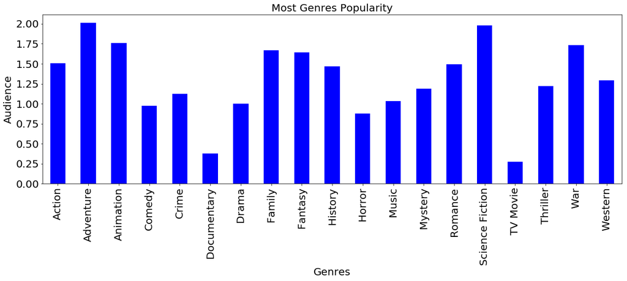

```python
bar1 = genres_audience.plot.bar(color = 'blue', fontsize = 20, figsize=(20, 6))
plt.xlabel('Genres',fontsize = '20')
plt.ylabel('Audience',fontsize = '20')
plt.title('Most Genres Popularity',fontsize = '20')
plt.show()
```

> **The bar graph show that the adventure moives is the top one.**

### What kinds of properties are associated with movies that have high revenues?

```python
biggest_revenue = df.sort_values(by=['revenue'], ascending = False).head(200)
```

```
Text(0.5,1,'properties of high revenues movies')
```

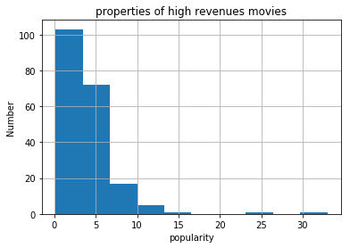

```python
ax = biggest_revenue.popularity.hist()
ax.set_ylabel('Number')
ax.set_xlabel('popularity')
ax.set_title('properties of high revenues movies')
```

```
Text(0.5,1,'properties of high revenues movies')
```

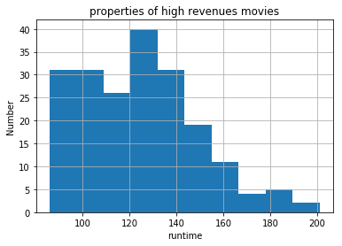

```python
ay = biggest_revenue.runtime.hist()
ay.set_ylabel('Number')
ay.set_xlabel('runtime')
ay.set_title('properties of high revenues movies')
```

```python
shortest_movies = df.sort_values(by=['runtime'], ascending = False).head(200)
runtime = shortest_movies['runtime']
popularity = shortest_movies['popularity']
```

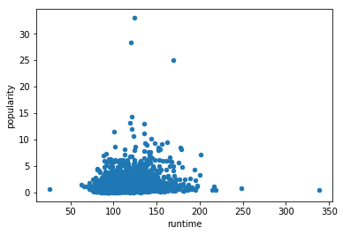

```python
az = df.plot(x='runtime', y='popularity', kind='scatter')
```

> **Most of the the movies with high revenue had some properties like the popularity around 2.5 and it's run time is between 100-130 min.**

> **For more profit the company should study the relation between the runtime and popularity very well.**

### Which cast is most popular ?

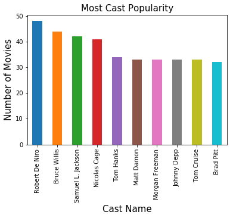

```python
cast = divide('cast')
top_cast = cast.head(10)
top_cast_bar = top_cast.plot.bar(fontsize = 10)
plt.xlabel('Cast Name',fontsize = '15')
plt.ylabel('Number of Movies',fontsize = '15')
plt.title('Most Cast Popularity',fontsize = '15')
plt.show()
```

> **Robert De Niro is the most cast popularity with more than 45 movies.**

### Which director is most popular ?

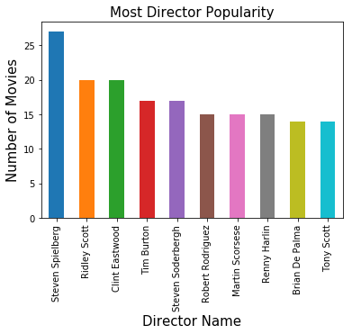

```python
director = divide('director')
top_director = director.head(10)
top_director_bar = top_director.plot.bar(fontsize = 10)
plt.xlabel('Director Name',fontsize = '15')
plt.ylabel('Number of Movies',fontsize = '15')
plt.title('Most Director Popularity',fontsize = '15')
plt.show()
```

> **Steven Spielberg is the most director popularity with more than 25 movies.**

### Which production company is most popular ?

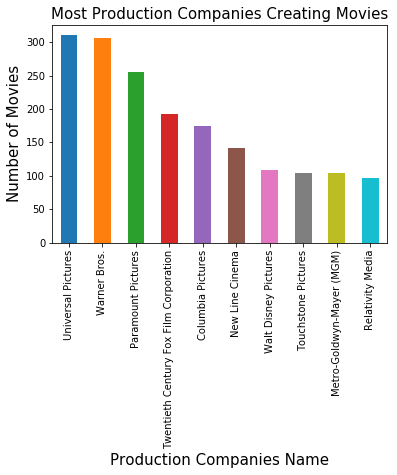

```python
production_companies = divide('production_companies')
top_production_companies = production_companies.head(10)
top_production_companies_bar = top_production_companies.plot.bar(fontsize = 10)
plt.xlabel('Production Companies Name',fontsize = '15')
plt.ylabel('Number of Movies',fontsize = '15')
plt.title('Most Production Companies Creating Movies',fontsize = '15')
plt.show()
```

> **Universal Pictures is the most production company producing movies with more thaan 300 movie.**

## Conclusions

> **My findings are:**

> 1 - There are a lot of missing data that can may affect the anlysis.

> 2 - Adventure moives is the most popular movie type.

> 4 - The most popular cast, On this list, Robert De Niro is at the top.

> 5 - The most popular director, On this list,Steven Spielberg is at the top.

## limitations

> 1 - Drop a lot of rows because they were filled with missing values that can affect the analysis output.

> 2 - Columns like budget and revenue had no currency unit.

```python
from subprocess import call
call(['python', '-m', 'nbconvert', 'Investigate_a_Dataset.ipynb'])
```

```
0
```